# LocalGLMnet及其LASSO正则

王晗

2022-04-21

class: middle

## **背景**：机器学习模型在预测能力上优于传统的回归模型，然而由于其解释能力差，被称为“**黑匣子**”

class: center, middle

# 打开“黑匣子”！

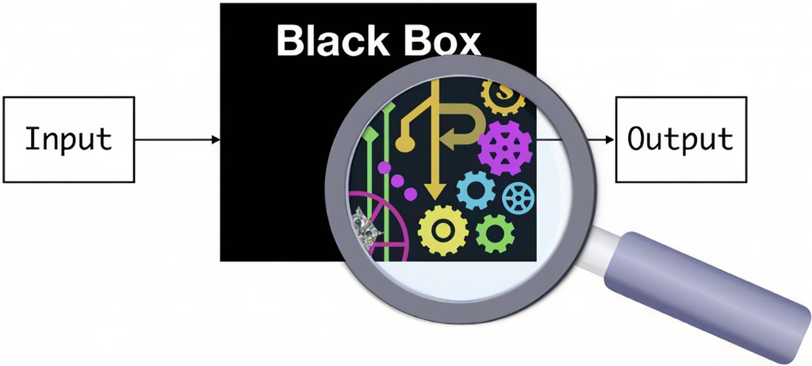

## 研究现状

1. 后验解释性（Post-Hoc Interpretability）

设计后验的模型解释工具

–

1. 内禀解释性（Intrinsic Interpretability）

设计易解释的模型架构

## 后验解释性（Post-Hoc Interpretability）

### 全局解释性（Global）

–

.pull-left[ - 变量重要性（VI）

特征分裂次数或分裂后的信息增益

- 2001，置换重要性（Permutation Importance）

  置换模型（随机打乱某特征取值）损失和原始模型损失的差异
- 2001，部分依赖图（Partial Dependence Plot，PDP）
- 2015，个体条件期望图（Individual Conditional Expectations，ICE）

]

.pull-right[ - 2020，累积局部效应图（Accumulated Local Effects，ALE）

可消除变量相关性的干扰，剥离出特征的纯粹影响。

将特征划分为一系列小的区间，指定某一区间，对落在该区间的每个样本点，计算模型在区间两端点预测值的差。对落在该区间的所有样本点，将前述差值取平均即为局部效应（Local Effect），反映特征在该区间对预测变量的影响。

将各个区间的局部效应累积，能反映该特征对预测变量的整体影响。 ]

## 后验解释性（Post-Hoc Interpretability）

### 局部解释性（Local）

–

- 2016，LIME（Local Interpretable Model-agnostic Explanation）

  可理解为局域的代理模型（Surrogate Model）。
  1. 选取目标样本，将输入值在其邻域内做微小扰动，从而构建新的建模数据集，并根据扰动点到原始数据点的距离分配权重。
  2. 基于新数据集训练一个代理模型。
- 2017，SHAP（SHapley Additive exPlanation）

  主要思想来源于Shapley在1953年创造的Shapley值。Shapley值来自合作博弈论（cooperative game theory），旨在基于各成员的贡献提供一个公平的分配。

## 后验解释性（Post-Hoc Interpretability）

### Shapley值思想：萧峰虚竹段誉三兄弟大战辽兵

–

.pull-left[ - 萧峰 = 300

- 虚竹 = 200
- 段誉 = 100
- 萧峰+虚竹 = 700
- 萧峰+段誉 = 500
- 虚竹+段誉 = 350
- 萧峰+虚竹+段誉 = 1000 ]

–

## 内禀解释性（Intrinsic Interpretability）

–

.pull-left[ - 1986，决策树]

## 内禀解释性（Intrinsic Interpretability）

.pull-left[

- 1986，决策树
- 2019，CANN模型（将GLM嵌入到神经网络中）

  优点：线性分量的预测可解释（自变量的线性组合），且线性分量和非线性分量对预测的贡献可比较。

]

.pull-right[

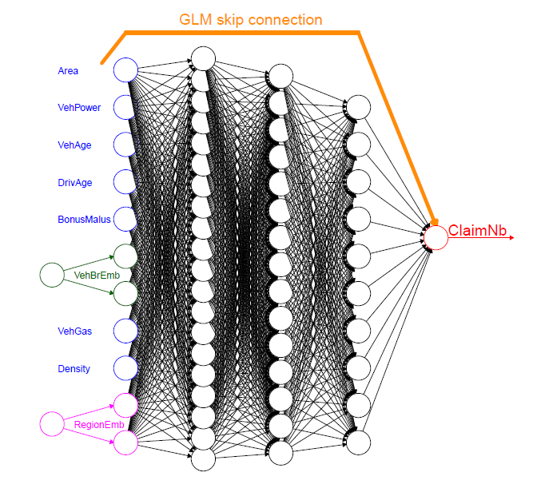

CANN模型结构

]

## 内禀解释性（Intrinsic Interpretability）

.pull-left[

- 1986，决策树
- 2019，CANN模型（将GLM嵌入到神经网络中）

  优点：线性分量的预测可解释（自变量的线性组合），且线性分量和非线性分量对预测的贡献可比较。
- 2019，可解释神经网络（xNN） ]

.pull-right[

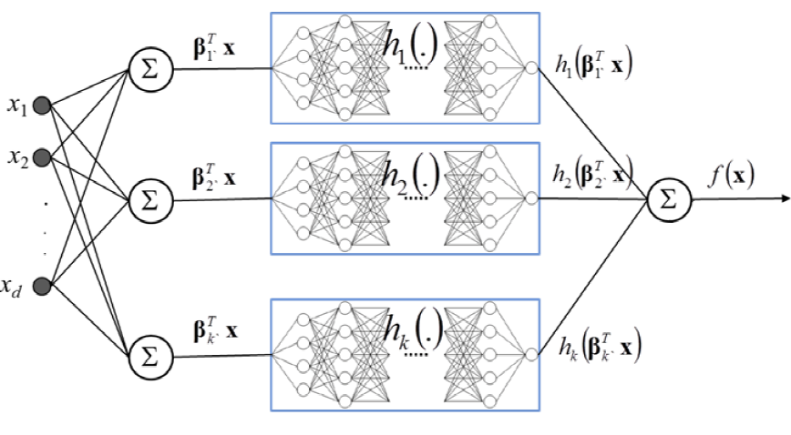

xNN模型结构

]

## 内禀解释性（Intrinsic Interpretability）

.pull-left[

- 1986，决策树
- 2019，CANN模型（将GLM嵌入到神经网络中）

  优点：线性分量的预测可解释（自变量的线性组合），且线性分量和非线性分量对预测的贡献可比较。
- 2019，可解释神经网络（xNN）
- 2021，神经可加模型（NAM）

xNN和NAM的共同点都是**通过相互分离的并行网络处理特征成分的不同子集**，一定程度上限制了变量间交互作用的提取。 ]

.pull-right[

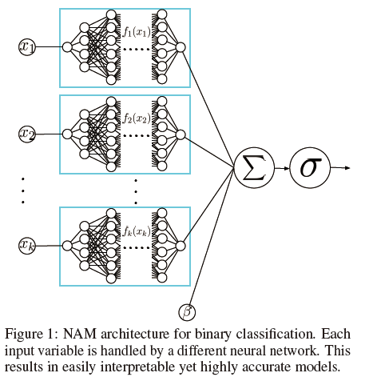

NAM模型结构

## ]

## 内禀解释性（Intrinsic Interpretability）

- 1986，决策树
- 2019，CANN模型（将GLM嵌入到神经网络中）

  优点：线性分量的预测可解释（自变量的线性组合），且线性分量和非线性分量对预测的贡献可比较。
- 2019，可解释神经网络（xNN）
- 2021，神经可加模型（NAM）

  xNN和NAM的共同点都是**通过相互分离的并行网络处理特征成分的不同子集**，一定程度上限制了变量间交互作用的提取。
- 2021，CAXNN模型（用xNN拟合CANN中的非线性分量）

–

同理可得CANAM？

class:middle,center,inverse

# LocalGLMnet

# ≈

# DNN的拟合能力

–

# +

# GLM的解释能力

## 模型简介

LocalGLMnet模型可以理解为一种特殊的GLM，其回归系数由神经网络训练，且与特征 $\pmb x$ 相关，即 $\beta_j=\beta_j(\pmb x)$ 。

严格讲，LocalGLMnet不再是线性模型，因其失掉了“参数线性”。其结构可表示为：

$$\pmb x\rightarrow g(\mu(\pmb x))=\beta_0+\langle\pmb\beta(\pmb x),x\rangle$$

作为对比，GLM的结构可表示为： $\pmb x\rightarrow g(\mu(\pmb x))=\beta_0+\langle\pmb\beta,x\rangle$

上述结构是一个带有**跳跃连接**的特殊的DNN。

- 首先，特征 $\pmb x$ 通过 $d$ 层全连接网络得到 $\pmb \beta(\pmb x)\in \mathbb R^q$ ;
- 然后，特征 $\pmb x$ 跳过所有全连接层直接连到输出层，与 $\pmb \beta(\pmb x)$ 作点乘。

自然地， $\pmb \beta(\pmb x)$ 就可以看作 $\pmb x$ 的“回归系数”，本文称之为**回归注意力**<sup>1</sup>（regression attention）。

.footnote[ [1] 若参数与特征 $x$ 不相关，称 $\beta$ **回归系数**；若参数与特征 $x$ 相关，称 $\beta(\pmb x)$ **回归注意力**。] —

```r
library(keras)
Design <- layer_input(shape=8 , dtype='float32', name='Design')
Attention <- Design %>%
  layer_dense(units=15, activation='tanh', name='FNLayer1') %>%
  layer_dense(units=10, activation='tanh', name='FNLayer2') %>%
  layer_dense(units=8, activation='linear', name='Attention')
Response <- list(Design, Attention) %>%
  layer_dot(axes=1, name='LocalGlm') %>%
  layer_dense(units=1, activation='exponential', name='Response')
keras_model(inputs=c(Design), outputs=c(Response))
```

```
## Model: "model"
## ____________________________________________________________
## Layer (type)       Output Shape  Param  Connected to
## ============================================================
## Design (InputLayer [(None, 8)]   0
## ____________________________________________________________
## FNLayer1 (Dense)   (None, 15)    135    Design[0][0]
## ____________________________________________________________
## FNLayer2 (Dense)   (None, 10)    160    FNLayer1[0][0]
## ____________________________________________________________
## Attention (Dense)  (None, 8)     88     FNLayer2[0][0]
## ____________________________________________________________
## LocalGlm (Dot)     (None, 1)     0      Design[0][0]
##                                         Attention[0][0]
## ____________________________________________________________
## Response (Dense)   (None, 1)     2      LocalGlm[0][0]
## ============================================================
## Total params: 385
## Trainable params: 385
## Non-trainable params: 0
## ____________________________________________________________
```

## 正则化

1. 弹性网（Elastic Net）正则

$$\underset{W,\beta_0}{\arg\min}\frac{1}{n}\sum_{i=1}^nL\big(Y_i,\mu_{W,\beta_0}(\pmb x_i)\big)+\eta\big((1-\alpha)||\beta(\pmb x_i)||_2^2+\alpha||\beta(\pmb x_i)||_1\big)$$

其中 $\eta>0\wedge\alpha\in[0,1]$ 。

- $\alpha=0$ 时退化为岭正则， $\underset{W,\beta_0}{\arg\min}\frac{1}{n}\sum_{i=1}^nL\big(Y_i,\mu_{W,\beta_0}(\pmb x_i)\big)+\eta||\beta(\pmb x_i)||_2^2$
- $\alpha=1$ 时退化为LASSO正则， $\underset{W,\beta_0}{\arg\min}\frac{1}{n}\sum_{i=1}^nL\big(Y_i,\mu_{W,\beta_0}(\pmb x_i)\big)+\eta||\beta(\pmb x_i)||_1$ 。

–

2. 组LASSO正则

## $$\underset{W,\beta_0}{\arg\min}\frac{1}{n}\sum_{i=1}^nL\big(Y_i,\mu_{W,\beta_0}(\pmb x_i)\big)+\sum_{k=1}^K\eta_k||\beta_k(\pmb x_i)||_2$$

## LassoNet

.pull-left[
$$\pmb x\rightarrow \pmb\beta^T\pmb x+\Psi_W(\pmb x)\\\underset{W,\pmb \beta}{\arg\min}\frac{1}{n}\sum_{i=1}^nL\big(Y_i,\mu_{W,\pmb \beta}(\pmb x_i)\big)+\eta||\pmb \beta||_1\\subject\ to\ ||W_j^{(1)}||_\infty\le M|\beta_j|,\ j=1,...,q$$
]

.pull-right[

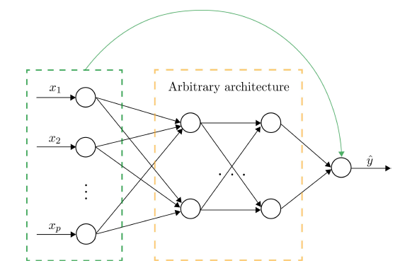

LassoNet模型结构

]

–

| Lasso-LocalGLMnet | LassoNet |  |
| --- | --- | --- |
| 正则化 | 激活正则 | 权重正则 |
| 参数 | $\eta$ | $\eta,M$ |
| 估参方法 | 梯度下降 | 近端梯度下降 (proximal gradient descent) |
| 方法有效性 | 较强 | 受非线性效应及变量间交互效应的影响较大 |
| 拓展性 | 强 | 弱 |

## 模拟数据分析

–

生成标准正态变量 $x_1,…,x_8$ ，其中 $corr(x_2,x_8)=0.5$ ，其余变量间均不相关。

数据量为20万，其中训练集为10万，测试集为10万。回归函数形式为：

–

$$\mu(x)=\frac{1}{2}x_1-\frac{1}{4}x_2^2+\frac{1}{2}|x_3|\sin(2x_3)+\frac{1}{2}x_4 x_5+\frac{1}{8} x_5^2x_6$$
$$y\sim \rm N\big(\mu(x),1\big)$$
–

基于模拟数据的各模型均方误差

| 训练集MSE | 测试集MSE |  |
| --- | --- | --- |
| 真实模型 | 1.0023 | 0.9955 |
| 空模型 | 1.7907 | 1.7916 |
| GLM | 1.5241 | 1.5274 |
| LocalGLMnet | 1.0023 | 1.0047 |

## 模拟数据分析

$\mu(x)=\frac{1}{2}x_1-\frac{1}{4}x_2^2+\frac{1}{2}|x_3|\sin(2x_3)+\frac{1}{2}x_4 x_5+\frac{1}{8} x_5^2x_6$

.pull-left[

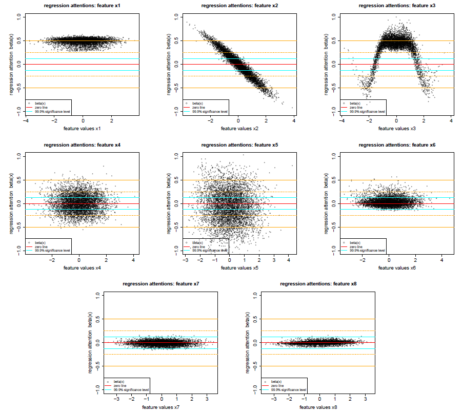

各变量的回归注意力

]

.pull-right[

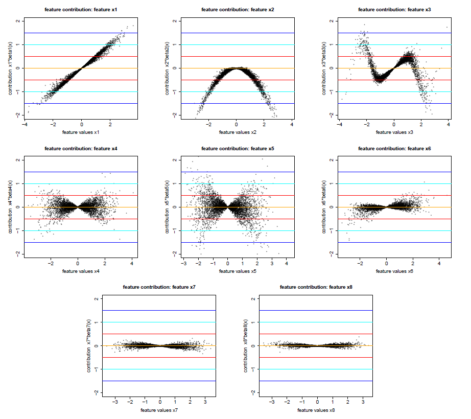

各变量的特征贡献

## ]

## 模拟数据分析

$\mu(x)=\frac{1}{2}x_1-\frac{1}{4}x_2^2+\frac{1}{2}|x_3|\sin(2x_3)+\frac{1}{2}x_4 x_5+\frac{1}{8} x_5^2x_6$

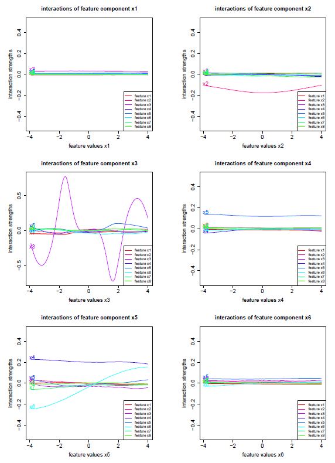

各变量间的交互效应

## 模拟数据分析

$\mu(x)=\frac{1}{2}x_1-\frac{1}{4}x_2^2+\frac{1}{2}|x_3|\sin(2x_3)+\frac{1}{2}x_4 x_5+\frac{1}{8} x_5^2x_6$

变量重要性: $VI_j(\eta)=\frac{1}{n}∑_{i=1}^n|\hat{\beta}_j^{(\eta)}(\pmb x_i)|$

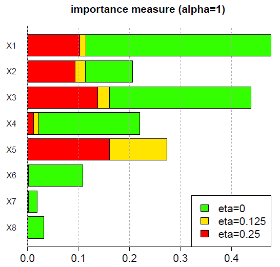

施加LASSO正则的变量重要性

## 分类变量处理

1. LocalGLMnet：**one-hot encoding**（P20）

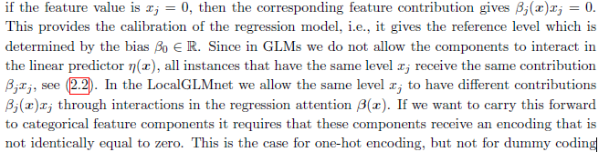

1. Lasso-LocalGLMnet：**scaled dummy-encoding**（P8）

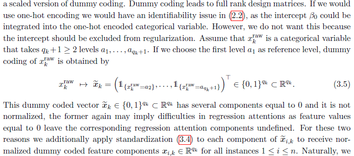

[figure not shown]

```r
plot(1:10)
```